# 5 Домашние задание по ТВиМС

### Импорт библиотек

```python
import numpy as np
import pandas as pd
import seaborn as sns
import matplotlib.pyplot as plt
from tqdm import tqdm

from scipy import stats
```

### Найстроки графиков

```python
sns.set(style="whitegrid")
```

## №1 Данные и гипотезы

Возьмем данные, которые были использованы в предыдущем задании из датасета [**kion**](https://github.com/irsafilo/KION_DATASET).

```python
users_df = pd.read_csv('data/users.csv')
items_df = pd.read_csv('data/items.csv')
interactions_df = pd.read_csv('data/interactions.csv')
```

Сформируем двухвыборочные гипотезы касательно медиан и распределений для дискретного и непрерывного случая.

### Гипотезы для дискретного случая

- Медиана зарплаты для мужчин и для женщин одинакова.
- Распределение зарплаты пользователей для мужчин и женщин одинаковы.

Зарплата в этих данных представлена как категориальный признак пользователя

```python
users_df['income'].unique()
```

```
array(['income_60_90', 'income_20_40', 'income_40_60', 'income_0_20', nan,
       'income_90_150', 'income_150_inf'], dtype=object)
```

```python
incomes = users_df[users_df['income'].notna() & users_df['sex'].notna()]
incomes = incomes[['income', 'sex']]

incomes['income'] = incomes['income'].map(lambda x: '_'.join(x.split('_')[1:]))

incomes.sample(3)
```

|  | income | sex |
| --- | --- | --- |
| 773853 | 20_40 | М |
| 514998 | 20_40 | М |
| 120429 | 20_40 | Ж |

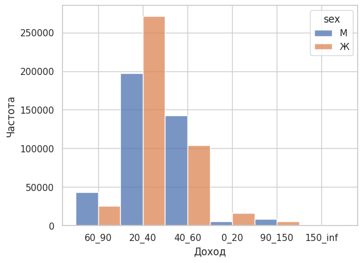

```python
sns.histplot(data=incomes,
             x='income',
             hue='sex',
             multiple="dodge")
plt.xlabel('Доход')
plt.ylabel('Частота')
plt.show()
```

Так как наши данные имеют порядковую структуру, будем это учитывать.

```python
incomes['numeric_income'] = incomes['income'].map(lambda x: int(x.split('_')[0]))
```

### Гипотзеы для непрерывного случая

- Медиана количества просмотренных фиьмов для мужчин и для женщин одинакова.
- Распределение количества просмотров пользователей для мужчин и женщин одинаковы

```python
views = interactions_df.groupby('user_id')\
                       .count()['item_id']\
                       .reset_index()\
                       .rename(columns={'item_id':'views'})

views = views.join(users_df[['user_id', 'sex']]\
             .set_index('user_id'))\
             .dropna()[['views', 'sex']]

views.sample(3)
```

|  | views | sex |
| --- | --- | --- |
| 402099 | 2 | Ж |
| 472850 | 2 | М |
| 865949 | 1 | М |

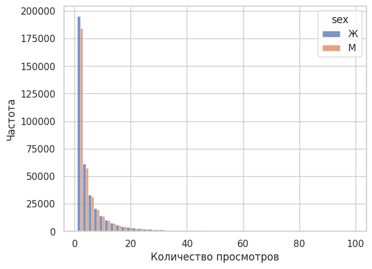

```python
sns.histplot(data=views.query('views < 100'),
             bins=50,
             x='views',
             hue='sex',
             multiple="dodge")
plt.xlabel('Количество просмотров')
plt.ylabel('Частота')
plt.show()
```

Прологарифмируем количество просмотов для каждого пользователя.

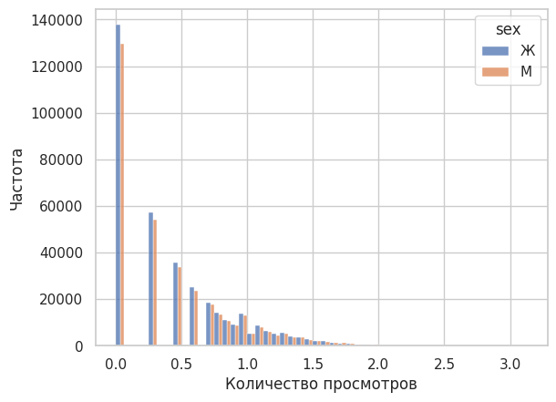

```python
log_views = views.copy()
log_views['views'] = np.log10(log_views['views'])

sns.histplot(data=log_views.query('views < 100'),
             bins=50,
             x='views',
             hue='sex',
             multiple="dodge")
plt.xlabel('Количество просмотров')
plt.ylabel('Частота')
plt.show()
```

## №2 Проверка гипотез статистическими тестами

### Дискретный случай

Для проверки гипотезы о сходстве медиан выборок будем использовать непараметрический [**U-критерий Манна — Уитни**](https://ru.wikipedia.org/wiki/U-%D0%BA%D1%80%D0%B8%D1%82%D0%B5%D1%80%D0%B8%D0%B9_%D0%9C%D0%B0%D0%BD%D0%BD%D0%B0_%E2%80%94_%D0%A3%D0%B8%D1%82%D0%BD%D0%B8). Он используется в том числе для проверки гипотезы о равенстве медианы в двух выборках. Единственное, что может останавливать нас от применения этого критерия это большая дисперсия, к счастью для нас, дисперсия маленькая.

```python
stats.mannwhitneyu(incomes[incomes['sex'] == 'М']['numeric_income'],
                   incomes[incomes['sex'] == 'Ж']['numeric_income']).pvalue
```

```
0.0
```

Для проверки гипотезы о сходстве выборорк будем использовать непараметрический [**критерий согласия Колмогорова**](https://ru.wikipedia.org/wiki/%D0%9A%D1%80%D0%B8%D1%82%D0%B5%D1%80%D0%B8%D0%B9_%D1%81%D0%BE%D0%B3%D0%BB%D0%B0%D1%81%D0%B8%D1%8F_%D0%9A%D0%BE%D0%BB%D0%BC%D0%BE%D0%B3%D0%BE%D1%80%D0%BE%D0%B2%D0%B0). Он используется для проверки гипотезы о равенстве функций распределений.

```python
stats.ks_2samp(incomes[incomes['sex'] == 'М']['numeric_income'],
               incomes[incomes['sex'] == 'Ж']['numeric_income']).pvalue
```

```
0.0
```

Как мы видим, выборки различны, как и медианы.

### Непрерывный случай

Для проверки гипотез будем использовать те же тесты, потому что они непараметрические - не требуют от данных "нормальности".

```python
stats.mannwhitneyu(views[views['sex'] == 'М']['views'],
                   views[views['sex'] == 'Ж']['views']).pvalue
```

```
0.9696475873120382
```

Тест Манна-Уитни очень чувствителен к дисперсии, проверим его на ошибки первого рода с помощью выделения подвыборок. В прошлый раз мы ты не делали, так так распределение у нас было дискртеное и дисперсия там была не такая большая.

```python
pvals = stats.mannwhitneyu(
            np.random.choice(views[views['sex'] == 'М']['views'], size=(1_000, 100), replace=False),
            np.random.choice(views[views['sex'] == 'Ж']['views'], size=(1_000, 100), replace=False)
        ).pvalue

print((np.array(pvals) < 0.05).mean())
```

```
0.07
```

На самом деле получислось неплохо.

Проверка сходства выборок.

```python
stats.ks_2samp(views[views['sex'] == 'М']['views'],
               views[views['sex'] == 'Ж']['views']).pvalue
```

```
0.9956273672367313
```

## №3 Проверка гипотез бутстрапом

Напишем две функции. Первая будет проверять гипотезу о равенстве медиан в выборках, вторая о равенстве распределений выборок. Проверка о равенстве распределений будет производится через вычисление моментов.

```python
def bootstrap_medians(sample1: pd.Series, sample2: pd.Series) -> tuple:
    medians1 = np.median(np.random.choice(sample1, size=(1_000, len(sample2)), replace=True),
                         axis=1)
    medians2 = np.median(np.random.choice(sample2, size=(1_000, len(sample2)), replace=True),
                         axis=1)

    return (np.quantile(medians1, [0.0025, 0.9975]).tolist(),
            np.quantile(medians2, [0.0025, 0.9975]).tolist())

def first_moment(data):
    return np.mean(data, axis=1)

def second_moment(data):
    mu_1 = first_moment(data)
    return np.mean((data - mu_1[:, np.newaxis])**2, axis=1)

def third_moment(data):
    mu_1 = first_moment(data)
    return np.mean((data - mu_1[:, np.newaxis])**3, axis=1)

def fourth_moment(data):
    mu_1 = first_moment(data)
    return np.mean((data - mu_1[:, np.newaxis])**4, axis=1)

def boostrap_moment(sample, moment_func) -> tuple:
    moments = moment_func(np.random.choice(sample,
                                           size=(1_000, len(sample)),
                                           replace=True))
    return np.quantile(moments, [0.025, 0.975]).tolist()

def boostrap_test(sample1, sample2):
    moments = [first_moment,
               second_moment,
               third_moment,
               fourth_moment]

    sample1_moments = []
    sample2_moments = []
    for moment in tqdm(moments):
        sample1_moments.append(boostrap_moment(sample1, moment))
        sample2_moments.append(boostrap_moment(sample2, moment))

    cnt = 0
    for (l1, r1), (l2, r2) in zip(sample1_moments, sample2_moments):
        print((l1, r1), (l2, r2))
        if l2 <= l1 <= r2 or l1 <= l2 <= r1 or l2 <= r1 <= r2 or l1 <= r2 <= r1:
            cnt += 1
    # Количество пересекающихся интервалов
    return cnt
```

```python
bootstrap_medians(incomes[incomes['sex'] == 'М']['numeric_income'],
                  incomes[incomes['sex'] == 'Ж']['numeric_income'])
```

```
([20.0, 20.0], [20.0, 20.0])
```

```python
boostrap_test(incomes[incomes['sex'] == 'М']['numeric_income'],
              incomes[incomes['sex'] == 'Ж']['numeric_income'])
```

```
(32.96820036167821, 33.06923446456283) (27.457014628839037, 27.546880876074695)
(287.01022396336043, 291.87982792824135) (227.6059149095965, 231.8053795582645)
(7174.326178233323, 7554.455973546427) (6093.077001621925, 6466.26358917997)
(600470.6663896433, 645196.009430405) (490763.3290725761, 535070.9208116384)
```

```
0
```

```python
bootstrap_medians(views[views['sex'] == 'М']['views'],
                  views[views['sex'] == 'Ж']['views'])
```

```
([2.0, 2.0], [2.0, 2.0])
```

```python
boostrap_test(views[views['sex'] == 'М']['views'],
              views[views['sex'] == 'Ж']['views'])
```

```
(5.66624537467612, 5.733456059067626) (5.663031405566046, 5.732837444210798)
(111.47777649468507, 123.21594390590133) (114.3024064346961, 135.72924917169553)
(9540.967707991176, 15303.458649981229) (10845.71926113877, 33176.1723446793)
(1644603.056109069, 5519850.633570825) (2158391.1634752136, 30906302.485107344)
```

```
4
```

## №4 Итог

Итак, мы увидели, что результаты отличаются только для дискретного случая медианы. Это произошло потому что в бутстрапе мы учитывали, что распределение у нас дискретное. А тест Манна-Уитни не значет ничего про нашу дискретность.

На самом деле я бы не использовал тест Манна-Уитни, а использоваль бы только тест Колмогорова-Смирнова + бутстрап, так как данные у нас не распределены нормально.